# Data Analysis Project

STAT 420, Fall 2024, C. Easton, A. Roh, T. Toter, A. Treptow

December 12, 2024

# Introduction

In this data analysis study, we applied the principles we learned during the semester to iteratively improve a linear regression model.

For our case study, we chose a “Wine Quality” dataset from the UC Irvine Machine Learning Repository. The data relates to red and white variants of the Portuguese vinho verde wine samples. We drew the data from the following site:

[UC Irvine Machine Learning Repository](https://archive.ics.uci.edu/dataset/186/wine+quality)

Each row in the dataset contains a record of 11 numerically measured physicochemical attributes, such as acidity, residual sugar, chlorides, and pH. We combined two datasets (one for white wine and one for red wine), resulting in an additional categorical attribute for wine type.

These 12 attributes served as our source predictor variables. A final attribute from the dataset measures quality, and serves as our response variable. Each quality measurement is a subjectively-assigned integer, ranging from 1 to 10. Our goal was to build a model that could use the objectively measured predictors as inputs to estimate how a human would rate each wine.

```r
options(repos = c(CRAN = "https://cloud.r-project.org"))
```

# Methods

## Data preparation

#### Load and Examine the Data

```r
library(dplyr)

red_wine = read.csv("winequality-red.csv", sep = ";")
white_wine = read.csv("winequality-white.csv", sep = ";")
# Add categorical variables for wine type
red_wine$type = "Red"
white_wine$type = "White"
wine_data = bind_rows(red_wine, white_wine) # Combine the two datasets
wine_data$type = as.factor(wine_data$type)
str(wine_data)
```

```
## 'data.frame':    6497 obs. of  13 variables:
##  $ fixed.acidity       : num  7.4 7.8 7.8 11.2 7.4 7.4 7.9 7.3 7.8 7.5 ...
##  $ volatile.acidity    : num  0.7 0.88 0.76 0.28 0.7 0.66 0.6 0.65 0.58 0.5 ...
##  $ citric.acid         : num  0 0 0.04 0.56 0 0 0.06 0 0.02 0.36 ...
##  $ residual.sugar      : num  1.9 2.6 2.3 1.9 1.9 1.8 1.6 1.2 2 6.1 ...
##  $ chlorides           : num  0.076 0.098 0.092 0.075 0.076 0.075 0.069 0.065 0.073 0.071 ...
##  $ free.sulfur.dioxide : num  11 25 15 17 11 13 15 15 9 17 ...
##  $ total.sulfur.dioxide: num  34 67 54 60 34 40 59 21 18 102 ...
##  $ density             : num  0.998 0.997 0.997 0.998 0.998 ...
##  $ pH                  : num  3.51 3.2 3.26 3.16 3.51 3.51 3.3 3.39 3.36 3.35 ...
##  $ sulphates           : num  0.56 0.68 0.65 0.58 0.56 0.56 0.46 0.47 0.57 0.8 ...
##  $ alcohol             : num  9.4 9.8 9.8 9.8 9.4 9.4 9.4 10 9.5 10.5 ...
##  $ quality             : int  5 5 5 6 5 5 5 7 7 5 ...
##  $ type                : Factor w/ 2 levels "Red","White": 1 1 1 1 1 1 1 1 1 1 ...
```

#### Remove Outliers

A few data points departed noticeably from the vast majority of the rest of the data. We removed some obvious outliers so we could pursue a model that handles the remainder of the data.

We viewed the data in a table, and identified the largest values for each column. We first noticed that there is a wine observation with a residual sugar value of 65.80, more than double that of the next wine observation.

```r
desc_res_sugar = wine_data[order(wine_data$residual.sugar, decreasing = TRUE), ]
head(desc_res_sugar, n = 3)
```

```
##      fixed.acidity volatile.acidity citric.acid residual.sugar chlorides
## 4381           7.8            0.965        0.60           65.8     0.074
## 3253           7.9            0.330        0.28           31.6     0.053
## 3263           7.9            0.330        0.28           31.6     0.053
##      free.sulfur.dioxide total.sulfur.dioxide density   pH sulphates alcohol
## 4381                   8                  160 1.03898 3.39      0.69    11.7
## 3253                  35                  176 1.01030 3.15      0.38     8.8
## 3263                  35                  176 1.01030 3.15      0.38     8.8
##      quality  type
## 4381       6 White
## 3253       6 White
## 3263       6 White
```

We also noticed that there is an unusual observation in the free sulfur dioxide column with a value of 289.0, almost double that of the next observation.

```r
desc_free_sulf_dio = wine_data[order(wine_data$free.sulfur.dioxide, decreasing = TRUE), ]
head(desc_free_sulf_dio, n = 3)
```

```
##      fixed.acidity volatile.acidity citric.acid residual.sugar chlorides
## 6345           6.1            0.260        0.25            2.9     0.047
## 3531           7.1            0.490        0.22            2.0     0.047
## 4650           6.2            0.255        0.24            1.7     0.039
##      free.sulfur.dioxide total.sulfur.dioxide density   pH sulphates alcohol
## 6345               289.0                440.0 0.99314 3.44      0.64    10.5
## 3531               146.5                307.5 0.99240 3.24      0.37    11.0
## 4650               138.5                272.0 0.99452 3.53      0.53     9.6
##      quality  type
## 6345       3 White
## 3531       3 White
## 4650       4 White
```

Keeping these data would hinder our ability to read and interpret the pairs plots, so we removed them.

```r
res_sugar_6580 = which(wine_data$residual.sugar == 65.80)
free_sulf_dio_289 = which(wine_data$free.sulfur.dioxide == 289.0)

remove_idx = c(res_sugar_6580, free_sulf_dio_289)
wine_data = wine_data[-remove_idx, ]
```

#### Split Data Into Train and Test

We performed an 80/20 test/train split on the data so that we could later check how our model would perform on unseen data, and to ensure that our model didn’t overfit to our data.

```r
set.seed(123)
trn_idx = sample(nrow(wine_data), size = 0.8 * nrow(wine_data))
wine_data_trn = wine_data[trn_idx, ]
wine_data_tst = wine_data[-trn_idx, ]
```

## Fit a Full Additive Model

We began by creating an additive model using all predictors without transformations. This model served as baseline to judge improvements for upcoming iterations.

```r
full_add_model = lm(quality ~ ., data = wine_data_trn)
(summary_full_model = summary(full_add_model))
```

```
##
## Call:
## lm(formula = quality ~ ., data = wine_data_trn)
##
## Residuals:
##     Min      1Q  Median      3Q     Max
## -3.5990 -0.4790 -0.0547  0.4615  2.7585
##
## Coefficients:
##                        Estimate Std. Error t value Pr(>|t|)
## (Intercept)           1.215e+02  1.734e+01   7.010 2.69e-12 ***
## fixed.acidity         9.617e-02  1.847e-02   5.206 2.01e-07 ***
## volatile.acidity     -1.509e+00  9.052e-02 -16.668  < 2e-16 ***
## citric.acid          -2.973e-02  8.892e-02  -0.334  0.73811
## residual.sugar        6.680e-02  6.976e-03   9.575  < 2e-16 ***
## chlorides            -6.780e-01  3.722e-01  -1.821  0.06860 .
## free.sulfur.dioxide   5.403e-03  8.745e-04   6.178 6.97e-10 ***
## total.sulfur.dioxide -1.112e-03  3.614e-04  -3.076  0.00211 **
## density              -1.210e+02  1.757e+01  -6.888 6.31e-12 ***
## pH                    5.754e-01  1.033e-01   5.570 2.68e-08 ***
## sulphates             7.099e-01  8.600e-02   8.255  < 2e-16 ***
## alcohol               2.137e-01  2.199e-02   9.718  < 2e-16 ***
## typeWhite            -4.454e-01  6.574e-02  -6.776 1.37e-11 ***
## ---
## Signif. codes:  0 '***' 0.001 '**' 0.01 '*' 0.05 '.' 0.1 ' ' 1
##
## Residual standard error: 0.7324 on 5183 degrees of freedom
## Multiple R-squared:  0.3047, Adjusted R-squared:  0.3031
## F-statistic: 189.3 on 12 and 5183 DF,  p-value: < 2.2e-16
```

This initial model had an Adjusted R-squared value of 0.303113. We sought to improve on that.

## Log Transform Predictors

To check whether some predictors should be log transformed, we began by fitting a model which was the additive model plus logs of all the variables besides citric acid (which had zero values).

```r
model_add = lm(quality ~ ., data = wine_data_trn)

model_add_log = lm(
  quality ~ fixed.acidity + log(fixed.acidity) +
    volatile.acidity + log(volatile.acidity) +
    citric.acid  +
    residual.sugar + log(residual.sugar) +
    chlorides + log(chlorides) +
    free.sulfur.dioxide + log(free.sulfur.dioxide) +
    total.sulfur.dioxide + log(total.sulfur.dioxide) +
    density + log(density) +
    pH + log(pH) +
    sulphates + log(sulphates) +
    alcohol + log(alcohol) +
    type,
  data = wine_data_trn
)

summary(model_add_log)
```

```
##
## Call:
## lm(formula = quality ~ fixed.acidity + log(fixed.acidity) + volatile.acidity +
##     log(volatile.acidity) + citric.acid + residual.sugar + log(residual.sugar) +
##     chlorides + log(chlorides) + free.sulfur.dioxide + log(free.sulfur.dioxide) +
##     total.sulfur.dioxide + log(total.sulfur.dioxide) + density +
##     log(density) + pH + log(pH) + sulphates + log(sulphates) +
##     alcohol + log(alcohol) + type, data = wine_data_trn)
##
## Residuals:
##     Min      1Q  Median      3Q     Max
## -3.2721 -0.4758 -0.0403  0.4562  2.6519
##
## Coefficients:
##                             Estimate Std. Error t value Pr(>|t|)
## (Intercept)               -1.233e+04  2.556e+03  -4.824 1.44e-06 ***
## fixed.acidity              7.922e-03  5.892e-02   0.134 0.893063
## log(fixed.acidity)         6.432e-01  4.516e-01   1.424 0.154406
## volatile.acidity          -4.267e-01  2.394e-01  -1.782 0.074817 .
## log(volatile.acidity)     -4.436e-01  8.648e-02  -5.130 3.01e-07 ***
## citric.acid                2.542e-02  8.894e-02   0.286 0.775062
## residual.sugar             2.062e-02  9.486e-03   2.174 0.029743 *
## log(residual.sugar)        2.406e-01  4.015e-02   5.994 2.19e-09 ***
## chlorides                 -3.499e-01  7.123e-01  -0.491 0.623283
## log(chlorides)            -3.981e-02  6.794e-02  -0.586 0.557913
## free.sulfur.dioxide       -1.030e-02  1.823e-03  -5.651 1.68e-08 ***
## log(free.sulfur.dioxide)   4.769e-01  5.173e-02   9.219  < 2e-16 ***
## total.sulfur.dioxide       1.320e-03  6.200e-04   2.129 0.033272 *
## log(total.sulfur.dioxide) -3.183e-01  5.595e-02  -5.688 1.35e-08 ***
## density                    1.233e+04  2.555e+03   4.828 1.42e-06 ***
## log(density)              -1.239e+04  2.545e+03  -4.869 1.15e-06 ***
## pH                        -2.931e+00  1.769e+00  -1.657 0.097507 .
## log(pH)                    1.124e+01  5.689e+00   1.975 0.048322 *
## sulphates                  4.712e-01  3.333e-01   1.414 0.157454
## log(sulphates)             1.616e-01  1.911e-01   0.845 0.397902
## alcohol                    6.079e-01  1.719e-01   3.536 0.000409 ***
## log(alcohol)              -4.648e+00  1.805e+00  -2.576 0.010033 *
## typeWhite                 -4.228e-01  6.901e-02  -6.127 9.62e-10 ***
## ---
## Signif. codes:  0 '***' 0.001 '**' 0.01 '*' 0.05 '.' 0.1 ' ' 1
##
## Residual standard error: 0.721 on 5173 degrees of freedom
## Multiple R-squared:  0.3276, Adjusted R-squared:  0.3247
## F-statistic: 114.5 on 22 and 5173 DF,  p-value: < 2.2e-16
```

In the summary of the model, we identified volatile.acidity, residual.sugar, free.sulfur.dioxide and total.sulfur.dioxide as predictors that had smaller p-values when log transformed.

We then created four separate models, each with a single, different variable logged. This allowed us to compare against the additive model.

```r
model_log1 = lm(quality ~ fixed.acidity + log(volatile.acidity) + citric.acid +
                 residual.sugar + chlorides + free.sulfur.dioxide +
                 total.sulfur.dioxide + density + pH + sulphates +
                 alcohol + type, data = wine_data_trn)

model_log2 = lm(quality ~ fixed.acidity + volatile.acidity + citric.acid +
                 log(residual.sugar) + chlorides + free.sulfur.dioxide +
                 total.sulfur.dioxide + density + pH + sulphates +
                 alcohol + type, data = wine_data_trn)

model_log3 = lm(quality ~ fixed.acidity + volatile.acidity + citric.acid +
                 residual.sugar + chlorides + log(free.sulfur.dioxide) +
                 total.sulfur.dioxide + density + pH + sulphates +
                 alcohol + type, data = wine_data_trn)

model_log4 = lm(quality ~ fixed.acidity + volatile.acidity + citric.acid +
                 residual.sugar + chlorides + free.sulfur.dioxide +
                 log(total.sulfur.dioxide) + density + pH + sulphates +
                 alcohol + type, data = wine_data_trn)

summary(model_add)$adj.r.squared
```

```
## [1] 0.303113
```

```r
summary(model_log1)$adj.r.squared
```

```
## [1] 0.3048577
```

```r
summary(model_log2)$adj.r.squared
```

```
## [1] 0.3017214
```

```r
summary(model_log3)$adj.r.squared
```

```
## [1] 0.3099875
```

```r
summary(model_log4)$adj.r.squared
```

```
## [1] 0.3021907
```

We noted improvement in Adjusted R-squared when free.sulfur.dioxide and volatile.acidity were logged. These two were then log transformed in further models.

```r
model_log = lm(quality ~ fixed.acidity + log(volatile.acidity) + citric.acid +
                 residual.sugar + chlorides + log(free.sulfur.dioxide) +
                 total.sulfur.dioxide + density + pH + sulphates +
                 alcohol + type, data = wine_data_trn)

summary(model_log)$adj.r.squared
```

```
## [1] 0.311381
```

The Adjusted R-squared of this model was higher than any of the four previous models compared.

## Multicollinearity

#### Variance Inflation Factors (VIF)

```r
if (!require(car)) install.packages("car")
library(car)
vif_values = vif(model_log)
vif_values
```

```
##            fixed.acidity    log(volatile.acidity)              citric.acid
##                 5.721540                 1.979825                 1.588657
##           residual.sugar                chlorides log(free.sulfur.dioxide)
##                10.295368                 1.664078                 2.440908
##     total.sulfur.dioxide                  density                       pH
##                 4.145973                25.994380                 2.694436
##                sulphates                  alcohol                     type
##                 1.581436                 6.597291                 7.700475
```

We saw a lot of multicollinearity in our data with density, residual.sugar, and type, all with VIF values over 5. We looked to a heatmap to understand how variables might be connected.

#### Predictor Correlation Heatmap

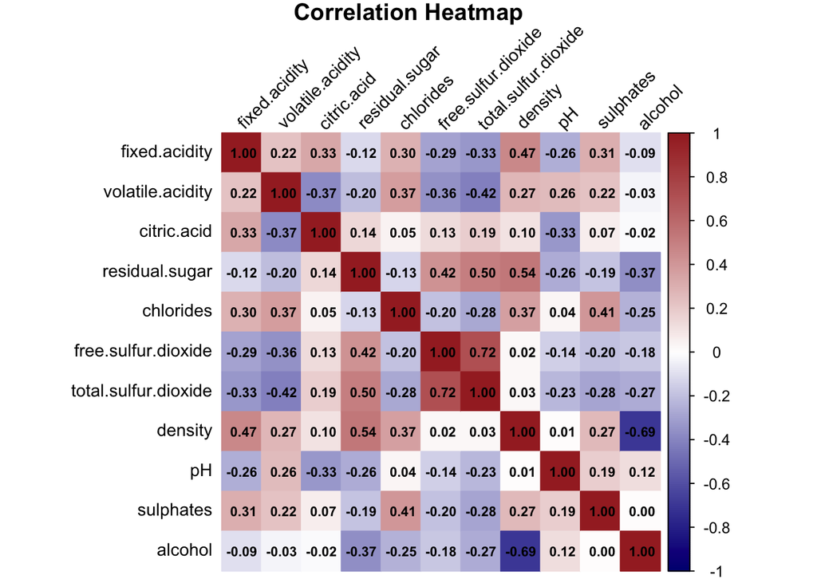

```r
if (!require(corrplot)) install.packages("corrplot")
library(corrplot)

numeric_data = wine_data_trn %>%
  select(-type, -quality) # Considers numeric predictors only
cor_matrix = cor(numeric_data, use = "complete.obs")
par(mar = c(0, 0, 5, 0))
corrplot(cor_matrix,
         method = "color",
         addCoef.col = "black",
         tl.cex = 0.9,
         tl.col = "black",
         tl.srt = 45,
         number.cex = 0.7,
         main = "Correlation Heatmap",
         cl.cex = 0.8,
         cl.ratio = 0.2,
         mar = c(0, 0, 1, 0),
         col = colorRampPalette(c("navy", "white", "brown"))(200)
)
```

We noticed that density was highly related to many other variables. We tried removing density to see if that improved multicollinearity in our model.

```r
model_log_noD = lm(quality ~ fixed.acidity + log(volatile.acidity) + citric.acid +
                 residual.sugar + chlorides + log(free.sulfur.dioxide) +
                 total.sulfur.dioxide + pH + sulphates +
                 alcohol + type, data = wine_data_trn)

vif_values = vif(model_log_noD)
vif_values
```

```
##            fixed.acidity    log(volatile.acidity)              citric.acid
##                 2.213922                 1.960247                 1.585956
##           residual.sugar                chlorides log(free.sulfur.dioxide)
##                 1.530790                 1.646703                 2.397533
##     total.sulfur.dioxide                       pH                sulphates
##                 4.005414                 1.594257                 1.474194
##                  alcohol                     type
##                 1.470429                 5.080319
```

## Summary of performance for various tested models

```r
summary(model_add)$adj.r.squared
```

```
## [1] 0.303113
```

```r
summary(model_log)$adj.r.squared
```

```
## [1] 0.311381
```

```r
summary(model_log_noD)$adj.r.squared
```

```
## [1] 0.3059458
```

We choose our no-density model as our best model so far, as it significantly improved our VIF values while maintaining a high Adjusted R-squared value relative to our other models.

## Examine quadratic transformation of non-logged variables.

To see whether any of our predictors could be improved by a quadratic transformation, we applied such a transformation to all of the non-logged variables from our best model. Backwards BIC selected four of these squared terms that we examined further.

```r
model_squared = lm(
  quality ~ fixed.acidity + I(fixed.acidity^2) +
    log(volatile.acidity) +
    citric.acid + I(citric.acid^2) +
    residual.sugar + I(residual.sugar^2) +
    chlorides + I(chlorides^2) +
    log(free.sulfur.dioxide) +
    total.sulfur.dioxide + I(total.sulfur.dioxide^2) +
    pH + I(pH^2) +
    sulphates + I(sulphates^2) +
    alcohol + I(alcohol^2) +
    type,
  data = wine_data)

n = nrow(wine_data)
model_squared_bic = step(
  model_squared,
  direction = "backward",
  k = log(n), trace = FALSE  # BIC criterion
)

summary(model_squared_bic)
```

```
##
## Call:
## lm(formula = quality ~ log(volatile.acidity) + citric.acid +
##     I(citric.acid^2) + residual.sugar + I(residual.sugar^2) +
##     chlorides + log(free.sulfur.dioxide) + total.sulfur.dioxide +
##     pH + I(pH^2) + sulphates + alcohol + I(alcohol^2) + type,
##     data = wine_data)
##
## Residuals:
##     Min      1Q  Median      3Q     Max
## -3.2383 -0.4688 -0.0259  0.4474  3.0721
##
## Coefficients:
##                            Estimate Std. Error t value Pr(>|t|)
## (Intercept)              -3.3899022  2.5900453  -1.309 0.190642
## log(volatile.acidity)    -0.5534792  0.0301066 -18.384  < 2e-16 ***
## citric.acid               0.6198634  0.1892730   3.275 0.001062 **
## I(citric.acid^2)         -0.8458089  0.2309027  -3.663 0.000251 ***
## residual.sugar            0.0424605  0.0068454   6.203 5.89e-10 ***
## I(residual.sugar^2)      -0.0012789  0.0003848  -3.324 0.000893 ***
## chlorides                -1.0903164  0.3277676  -3.326 0.000884 ***
## log(free.sulfur.dioxide)  0.2429246  0.0198489  12.239  < 2e-16 ***
## total.sulfur.dioxide     -0.0026303  0.0003222  -8.163 3.89e-16 ***
## pH                        4.9957904  1.5432369   3.237 0.001213 **
## I(pH^2)                  -0.7560319  0.2375147  -3.183 0.001464 **
## sulphates                 0.6260523  0.0729709   8.579  < 2e-16 ***
## alcohol                  -0.4187058  0.1375049  -3.045 0.002336 **
## I(alcohol^2)              0.0344785  0.0062781   5.492 4.13e-08 ***
## typeWhite                -0.1735176  0.0426725  -4.066 4.83e-05 ***
## ---
## Signif. codes:  0 '***' 0.001 '**' 0.01 '*' 0.05 '.' 0.1 ' ' 1
##
## Residual standard error: 0.7248 on 6480 degrees of freedom
## Multiple R-squared:  0.3117, Adjusted R-squared:  0.3102
## F-statistic: 209.6 on 14 and 6480 DF,  p-value: < 2.2e-16
```

```r
model_log_quad4 = lm(quality ~ fixed.acidity + log(volatile.acidity) + citric.acid +
                 I(citric.acid^2) + residual.sugar + I(residual.sugar^2)  + chlorides +
                 log(free.sulfur.dioxide) + total.sulfur.dioxide  + pH +
                 I(pH^2) + sulphates + alcohol +  I(alcohol^2) + type, data = wine_data_trn)

model_log_quad3 = lm(quality ~ fixed.acidity + log(volatile.acidity) + citric.acid +
                 I(citric.acid^2) + residual.sugar + I(residual.sugar^2)  + chlorides +
                 log(free.sulfur.dioxide) + total.sulfur.dioxide + pH +
                 sulphates + alcohol +  I(alcohol^2) + type, data = wine_data_trn)

model_log_quad2 = lm(quality ~ fixed.acidity + log(volatile.acidity) + citric.acid +
                 I(citric.acid^2) + residual.sugar + chlorides + log(free.sulfur.dioxide) +
                 total.sulfur.dioxide + pH + sulphates + alcohol +
                 I(alcohol^2) + type, data = wine_data_trn)

model_log_quad = lm(quality ~ fixed.acidity + log(volatile.acidity) + citric.acid +
                 residual.sugar + chlorides + log(free.sulfur.dioxide) +
                 total.sulfur.dioxide + pH + sulphates + alcohol +
                 I(alcohol^2) + type, data = wine_data_trn)

summary(model_log_noD)$adj.r.squared
```

```
## [1] 0.3059458
```

```r
summary(model_log_quad2)$adj.r.squared
```

```
## [1] 0.3098473
```

```r
summary(model_log_quad3)$adj.r.squared
```

```
## [1] 0.310536
```

```r
summary(model_log_quad4)$adj.r.squared
```

```
## [1] 0.3116507
```

We conducted ANOVA tests on models, incrementally adding quadratic terms for alcohol, citric.acid, residual.sugar, and pH. The addition of each term improved Adjusted R-squared and significantly improved model performance with ANOVA.

```r
anova(model_log_noD,model_log_quad)
```

```
## Analysis of Variance Table
##
## Model 1: quality ~ fixed.acidity + log(volatile.acidity) + citric.acid +
##     residual.sugar + chlorides + log(free.sulfur.dioxide) + total.sulfur.dioxide +
##     pH + sulphates + alcohol + type
## Model 2: quality ~ fixed.acidity + log(volatile.acidity) + citric.acid +
##     residual.sugar + chlorides + log(free.sulfur.dioxide) + total.sulfur.dioxide +
##     pH + sulphates + alcohol + I(alcohol^2) + type
##   Res.Df    RSS Df Sum of Sq      F    Pr(>F)
## 1   5184 2769.5
## 2   5183 2761.7  1    7.8081 14.654 0.0001307 ***
## ---
## Signif. codes:  0 '***' 0.001 '**' 0.01 '*' 0.05 '.' 0.1 ' ' 1
```

```r
anova(model_log_quad2,model_log_quad)
```

```
## Analysis of Variance Table
##
## Model 1: quality ~ fixed.acidity + log(volatile.acidity) + citric.acid +
##     I(citric.acid^2) + residual.sugar + chlorides + log(free.sulfur.dioxide) +
##     total.sulfur.dioxide + pH + sulphates + alcohol + I(alcohol^2) +
##     type
## Model 2: quality ~ fixed.acidity + log(volatile.acidity) + citric.acid +
##     residual.sugar + chlorides + log(free.sulfur.dioxide) + total.sulfur.dioxide +
##     pH + sulphates + alcohol + I(alcohol^2) + type
##   Res.Df    RSS Df Sum of Sq      F    Pr(>F)
## 1   5182 2752.9
## 2   5183 2761.7 -1   -8.8226 16.608 4.666e-05 ***
## ---
## Signif. codes:  0 '***' 0.001 '**' 0.01 '*' 0.05 '.' 0.1 ' ' 1
```

```r
anova(model_log_quad3,model_log_quad2)
```

```
## Analysis of Variance Table
##
## Model 1: quality ~ fixed.acidity + log(volatile.acidity) + citric.acid +
##     I(citric.acid^2) + residual.sugar + I(residual.sugar^2) +
##     chlorides + log(free.sulfur.dioxide) + total.sulfur.dioxide +
##     pH + sulphates + alcohol + I(alcohol^2) + type
## Model 2: quality ~ fixed.acidity + log(volatile.acidity) + citric.acid +
##     I(citric.acid^2) + residual.sugar + chlorides + log(free.sulfur.dioxide) +
##     total.sulfur.dioxide + pH + sulphates + alcohol + I(alcohol^2) +
##     type
##   Res.Df    RSS Df Sum of Sq      F  Pr(>F)
## 1   5181 2749.6
## 2   5182 2752.9 -1   -3.2777 6.1761 0.01298 *
## ---
## Signif. codes:  0 '***' 0.001 '**' 0.01 '*' 0.05 '.' 0.1 ' ' 1
```

```r
anova(model_log_quad3,model_log_quad4)
```

```
## Analysis of Variance Table
##
## Model 1: quality ~ fixed.acidity + log(volatile.acidity) + citric.acid +
##     I(citric.acid^2) + residual.sugar + I(residual.sugar^2) +
##     chlorides + log(free.sulfur.dioxide) + total.sulfur.dioxide +
##     pH + sulphates + alcohol + I(alcohol^2) + type
## Model 2: quality ~ fixed.acidity + log(volatile.acidity) + citric.acid +
##     I(citric.acid^2) + residual.sugar + I(residual.sugar^2) +
##     chlorides + log(free.sulfur.dioxide) + total.sulfur.dioxide +
##     pH + I(pH^2) + sulphates + alcohol + I(alcohol^2) + type
##   Res.Df    RSS Df Sum of Sq      F   Pr(>F)
## 1   5181 2749.6
## 2   5180 2744.7  1    4.9754 9.3902 0.002193 **
## ---
## Signif. codes:  0 '***' 0.001 '**' 0.01 '*' 0.05 '.' 0.1 ' ' 1
```

## Interaction terms

Although we had already lowered our VIF values to a reasonable range, we thought that there might be some remaining inter-connectedness between variables that, if accounted for with interaction terms, might improve the predictive power of our model. So we applied interaction terms between all our variables and used various strategies to select those which improved our model.

```r
model_log_int = lm(quality ~ (fixed.acidity + log(volatile.acidity) + citric.acid +
                 I(citric.acid^2) + residual.sugar + I(residual.sugar^2)  + chlorides +
                 log(free.sulfur.dioxide) + total.sulfur.dioxide  + pH +
                 I(pH^2) + sulphates + alcohol +  I(alcohol^2) + type)^2,
                   data = wine_data_trn)
```

#### Akaike Information Criterion (AIC) and Bayesian Information Criteria (BIC) Modelling

We used back AIC and BIC to select predictors.

```r
model_bac_aic = step(model_log_int, trace = 0)
model_bac_bic = step(model_log_int, k = log(nrow(wine_data_trn)), trace = 0)
```

## Analysis of Variance (ANOVA)

We now have three potential interaction models. The full interactive model has 120 predictors, and our backwards AIC and BIC models have 68 and 41, respectively.

```r
num_predictors = data.frame(
  Model = c("model_log_quad4", "model_log_int", "model_bac_aic", "model_bac_bic"),
  `Number of Predictors` = c(
    length(model_log_quad4$coefficients) - 1,
    length(model_log_int$coefficients) - 1,
    length(model_bac_aic$coefficients) - 1,
    length(model_bac_bic$coefficients) - 1
  )
)

# Print the table
print(num_predictors)
```

```
##             Model Number.of.Predictors
## 1 model_log_quad4                   15
## 2   model_log_int                  120
## 3   model_bac_aic                   68
## 4   model_bac_bic                   41
```

We ran ANOVA between the models to determine which was best.

```r
anova(model_bac_aic, model_log_quad4)[["Pr(>F)"]]
```

```
## [1]           NA 1.386761e-86
```

```r
anova(model_bac_bic, model_log_quad4)[["Pr(>F)"]]
```

```
## [1]           NA 6.215628e-83
```

```r
anova(model_log_int, model_log_quad4)[["Pr(>F)"]]
```

```
## [1]           NA 4.715302e-68
```

All three of our interactive models were shown to be better than our non-interaction model as ANOVA tests between all three interactive models and the non-interactive model yielded small p-values (<0.05) such that the null hypotheses were rejected.

```r
(anova_aic_bic = anova(model_bac_bic, model_bac_aic)[["Pr(>F)"]])
```

```
## [1]           NA 1.473244e-09
```

```r
(anova_aic_int = anova(model_bac_aic, model_log_int)[["Pr(>F)"]])
```

```
## [1]        NA 0.9992359
```

ANOVA tests between the interactive models provided additional information. ANOVA between the AIC and BIC models had a very small p-value indicating the more complex model (AIC) was better. AIC versus model_log_int had a large p-value indicating that the smaller AIC model was better. As a result, we decided to proceed with `model_bac_aic` which also had the highest Adjusted R-squared at 0.3766545.

```r
# Create a table with Adjusted R-squared values
adj_r_squared_table = data.frame(
  Model = c("model_bac_aic", "model_bac_bic", "model_log_int"),
  `Adjusted R-squared` = c(
    summary(model_bac_aic)$adj.r.squared,
    summary(model_bac_bic)$adj.r.squared,
    summary(model_log_int)$adj.r.squared
  )
)

print(adj_r_squared_table)
```

```
##           Model Adjusted.R.squared
## 1 model_bac_aic          0.3766545
## 2 model_bac_bic          0.3683084
## 3 model_log_int          0.3734165
```

## Remove more outliers

Having established a solid model, we used Cook’s distance to further remove outliers.

```r
mod_cd = cooks.distance(model_bac_aic)

model_bac_aic_cd = lm(formula(model_bac_aic), data = wine_data_trn,
                 subset = mod_cd < 4 / length(mod_cd))

summary(model_bac_aic_cd)$adj.r.squared
```

```
## [1] 0.4323089
```

# Results

## Linear Model Assumption Diagnostic Plots

A Residuals versus Fitted plot showed that the data was pretty well evenly distributed, perhaps with some clustering in the middle of the graph that could have to do with the subjective grading scale of the response.

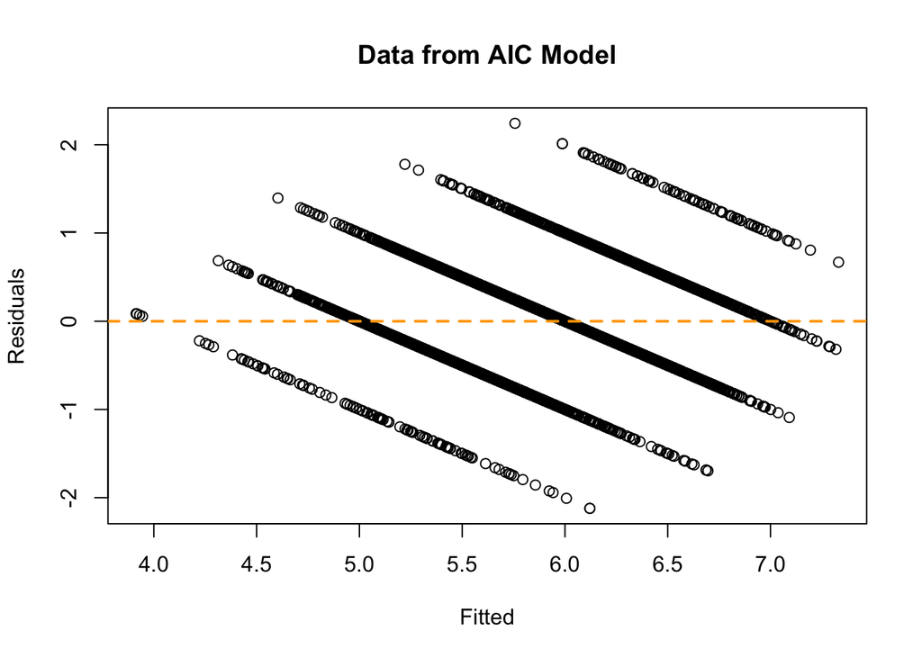

```r
plot(fitted(model_bac_aic_cd), resid(model_bac_aic_cd),
     xlab = "Fitted", ylab = "Residuals",
     main = "Data from AIC Model")
abline(h = 0, col = "orange", lwd = 2, lty = 2)
```

Our Normal Q-Q plot indicated that the residuals were normally distributed as most points fell along the center line.

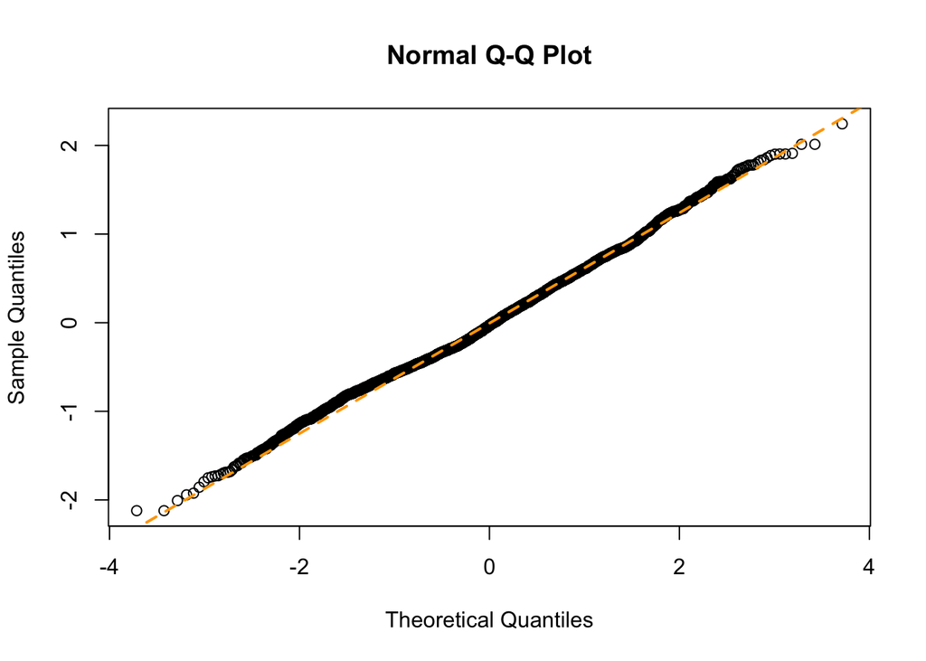

```r
qqnorm(resid(model_bac_aic_cd), main = "Normal Q-Q Plot")
qqline(resid(model_bac_aic_cd),
       col = "orange", lty = 2, lwd = 2)
```

## Evaluating our Model

```r
rmse = function(actual, predicted) {
  sqrt(mean((actual - predicted)^2))
}
```

```r
(rmse_trn = rmse(wine_data_trn$quality, predict(model_bac_aic_cd, wine_data_trn)))
```

```
## [1] 0.6923946
```

```r
(rmse_tst = rmse(wine_data_tst$quality, predict(model_bac_aic_cd, wine_data_tst)))
```

```
## [1] 0.6863045
```

We were pleased with the RMSE of our final model. The values were similar for the test and train, indicating we were not overfitting. Overall our RMSE was 0.6863045 on test data, indicating that on average, our predicted quality score was well within one point of the actual score.

# Discussion

We arrived at our best model through a backward step AIC upon an interaction model, containing transformations on selected predictors.

To arrive at this model, we took the steps of examining a full additive model, log transforming the variables with skewed distributions, addressing multicollinearity between predictors, and experimenting with polynomial terms and interactions.

After developing a satisfactory model, we sought to refine it further by exploring interactive models and employing both AIC and BIC modeling techniques. We reached two models: `model_bac_aic` with 68 coefficients, and `model_bac_bic` with 41 coefficients.

Both of these models gave very similar Adjusted R-squared values (0.3766545 for AIC and 0.3683084 for BIC). Given these two values were very similar, we decided the BIC model would be better, since it had far fewer predictors, making it much easier to interpret the model. However, we checked if the extra predictors (from the AIC model) are needed with an analysis of variance (ANOVA).

Running an analysis of variance between the AIC and BIC model gave a p-value of 1.4732435^{-9}, suggesting that the smaller model should be rejected in favor of the larger model. As a sanity check, we also run an ANOVA test of our larger AIC model against the full-interactive model and got a p-value of 0.9992359. Since this is larger than 0.05, we favor the smaller model (AIC) over the larger model (full-interactive).

We choose our AIC model to be our favorite model. To clean up the data for our model, we use Cook’s distance to exclude outliers from the model. With our final model, `model_bac_aic_cd`, we achieve an Adjusted R-squared value of 0.4323089.

We performed final checks on our final model to ensure that it obeyed the linear model assumptions.

Finally, we evaluated how our model performs by getting the RMSE on our test data. We see that on average, our model is off by 0.6863045 on a 1 to 10 scale.